# Exam 1

## Exam 1

#### Question

1. En La Tebaida se realizó un(a) estudio a un grupo de colaboradores de un(a) entidad sobre el tipo de bienes que poseen. Los(las) datos se presentan en la gráfica.

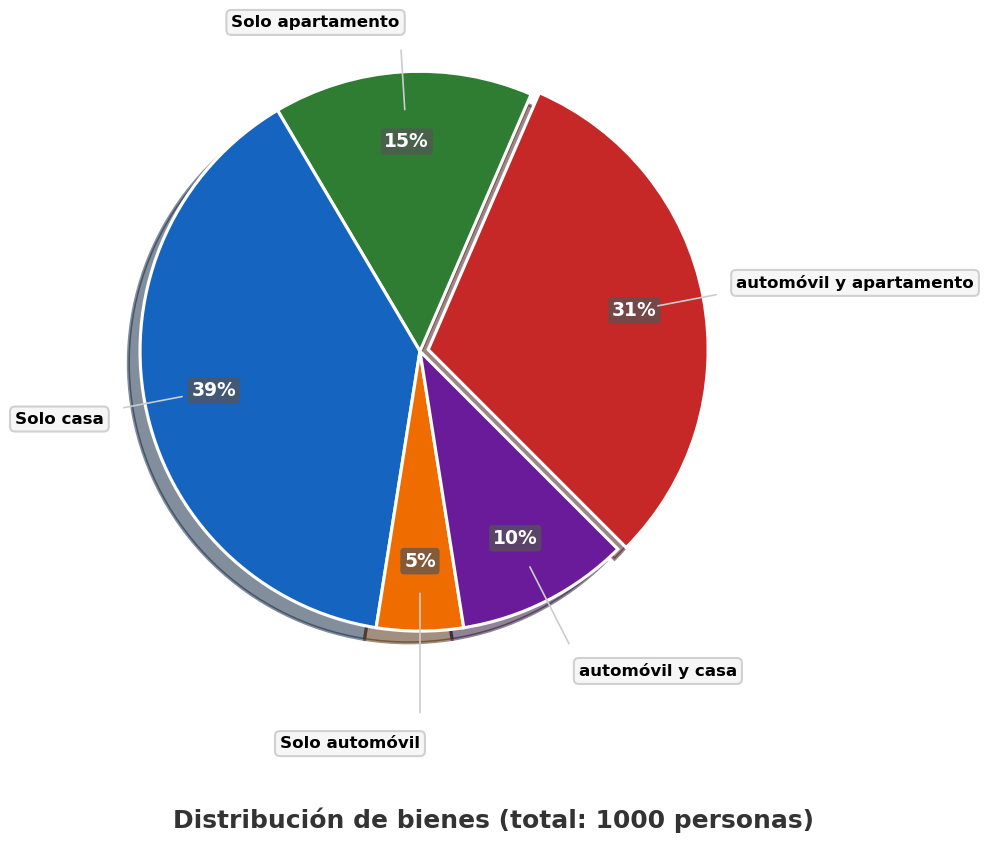

   1. Según el gráfico, si 150 colaboradores de la entidad poseen solo apartamento, ¿cuántos colaboradores poseen automóvil y apartamento?
   2. Si se escoge una persona del grupo al azar, ¿cuál es la probabilidad de que tenga solo casa? (Exprese la respuesta como un número decimal con 4 decimales, por ejemplo: 0.2500)
   3. ¿Cuántas personas de la entidad fueron encuestadas en total?

#### Solution

   Para resolver este problema, necesitamos analizar la información proporcionada en el gráfico circular y aplicar conceptos de proporcionalidad y probabilidad.

### Pregunta 1: Número de personas que poseen automóvil y apartamento

   Sabemos que 150 colaboradores poseen solo apartamento, lo que representa el 15% del total según el gráfico.

   Para calcular el total de personas:

   ```
   Total = (valor_conocido × 100%) ÷ porcentaje_conocido
   Total = (150 × 100%) ÷ 15%
   Total = (150 × 100) ÷ 15
   Total = 15000 ÷ 15
   Total = 1000.0000
   Total = 1000 colaboradores
   ```

   Ahora podemos calcular cuántas personas poseen automóvil y apartamento:
   - Según el gráfico, las personas con automóvil y apartamento representan el 31% del total.

   ```
   Número de personas = (porcentaje_buscado × total_personas) ÷ 100%
   Número de personas = (31% × 1000) ÷ 100%
   Número de personas = (31 × 1000) ÷ 100
   Número de personas = 31000 ÷ 100
   Número de personas = 310.0000
   Número de personas = 310 colaboradores
   ```

### Pregunta 2: Probabilidad de que una persona tenga solo casa

   La probabilidad se calcula dividiendo el número de casos favorables entre el número total de casos posibles:
   - Número de personas con solo casa = 390 colaboradores
   - Total de personas = 1000 colaboradores
   - Probabilidad = 390 ÷ 1000
   - Probabilidad = 0.3900

### Pregunta 3: Total de personas encuestadas en la entidad

   Como calculamos en la primera pregunta, el total de personas encuestadas en la entidad es 1000 colaboradores.

   Verificación de la coherencia de datos: * automóvil y apartamento: 310 colaboradores (31% del total) * Solo apartamento: 150 colaboradores (15% del total) * Solo casa: 390 colaboradores (39% del total) * Solo automóvil: 50 colaboradores (5% del total) * automóvil y casa: 100 colaboradores (10% del total)

   La suma de todas estas categorías es 1000 colaboradores, que coincide exactamente con nuestro total calculado de 1000 colaboradores.
   1. La respuesta es 310.
   2. La respuesta es 0.39.
   3. La respuesta es 1000.